# L5 多元正态和多元变量分析

Wangcheng Li

2023-09-27

```r
X = matrix(runif(300),100,3)
```

# 1 多元正态和多元变量分析

## 1.1 均值向量和协方差矩阵的计算，相关系数矩阵的计算

查看多元变量的均值向量、协方差矩阵和相关系数矩阵是多元变量分析的基础。考虑样本矩阵 $\mathbf{X}_{n\times p}$ ，我们可以使用 `apply` 函数来计算其均值向量。该函数的含义是，对目标矩阵，在指定方向上（行或者列），执行相同的操作。例如：

```r
apply(
  X, # 目标矩阵
  2, # 1为行，2为列
  mean # 对每一列执行均值函数
)
```

```
## [1] 0.4887631 0.4969570 0.5392584
```

使用内置的 `cov` 和 `cor` 函数，可以对目标样本矩阵分别计算协方差矩阵和相关系数矩阵。这两个函数均将每一列视作一个变量，每一行视作一个样本观测值。代码实现如下：

```r
f = function(){
  cat("协方差矩阵：","\n")
  print(cov(X))
  cat("相关系数矩阵：","\n")
  print(cor(X))
}
f()
```

```
## 协方差矩阵：
##             [,1]        [,2]        [,3]
## [1,] 0.068566455 0.002245367 0.006854713
## [2,] 0.002245367 0.087329608 0.005494013
## [3,] 0.006854713 0.005494013 0.073838628
## 相关系数矩阵：
##            [,1]       [,2]       [,3]
## [1,] 1.00000000 0.02901688 0.09633666
## [2,] 0.02901688 1.00000000 0.06841749
## [3,] 0.09633666 0.06841749 1.00000000
```

## 1.2 多元正态数据的生成（MASS和手动生成）

考虑一个多元正态分布 $N (\mu, \Sigma)$，我们希望从中生成 $n$ 个样本，并以样本矩阵 $\mathbf{X}_{n\times p}$ 的形式保存。我们这里介绍两种方法：手动计算和引用 R 包。

### 1.2.1 手动生成

**手动计算** 我们知道，多元正态分布可以表示为标准多元正态分布 $Y \sim N(0,I_p)$ 的线性组合：

$$X = \Sigma^{1/2}Y + \mu$$

因此，只需要生成标准多元正态分布的样本矩阵 $\mathbf{Y}$ ，而后进行线性变化，即可获得所需的多元正态分布。代码展示如下：

```r
### 生成标准多元正态分布 Y
n = 10000
p = 3
Y = matrix(rnorm(n*p),n,p)
```

```r
### 给定均值向量和协方差矩阵
mu = c(1,2,-1)
Sigma = matrix(
  c(
    1,0.5,0.2,
    0.5,1,0.5,
    0.2,0.5,1
  ),3,3
)
```

```r
### 计算协方差矩阵的根号结果
eig = eigen(Sigma)
sqrt_Sigma = eig$vectors %*% diag(sqrt(eig$values))
sqrt_Sigma
```

```
##            [,1]          [,2]       [,3]
## [1,] -0.7190573  6.324555e-01  0.2880219
## [2,] -0.8832078  1.837075e-15 -0.4689819
## [3,] -0.7190573 -6.324555e-01  0.2880219
```

```r
### 生成 X
X = Y %*% t(sqrt_Sigma) + matrix(mu,n,p,byrow = T)
```

```r
### 展示
f = function(){
  cat("均值向量","\n")
  print(apply(X,2,mean))
  cat("协方差矩阵","\n")
  print(cov(X))
}
f()
```

```
## 均值向量
## [1]  1.0078921  2.0167548 -0.9746613
## 协方差矩阵
##           [,1]      [,2]      [,3]
## [1,] 0.9737362 0.4895152 0.2053579
## [2,] 0.4895152 0.9815495 0.4938710
## [3,] 0.2053579 0.4938710 1.0020997
```

### 1.2.2 使用 R 包生成

```r
# install.packages("MASS")
library(MASS)
X = mvrnorm(n,mu,Sigma)
f()
```

```
## 均值向量
## [1]  1.006686  1.987121 -1.012957
## 协方差矩阵
##           [,1]      [,2]      [,3]
## [1,] 0.9854182 0.4983408 0.2012689
## [2,] 0.4983408 1.0030498 0.5054795
## [3,] 0.2012689 0.5054795 1.0103270
```

## 1.3 正态数据的可视化

### 1.3.1 一元正态数据的可视化

我们之前讲过使用直方图、密度函数图、QQ图来展示一个变量的正态分布性质。这里，我们简单回顾一下:

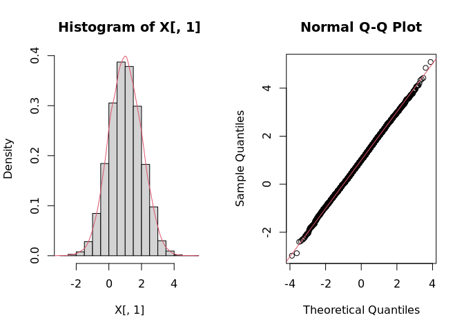

```r
par(mfrow = c(1,2))
hist(X[,1],freq = F)
lines(density(X[,1]),col = 2)
qqnorm(X[,1])
qqline(X[,1],col = 2)
```

```r
par(mfrow = c(1,1))
```

### 1.3.2 二元正态数据的可视化

我们之前同样讲过二元数据的可视化问题，主要包括绘制二元变量的密度图像（平面图像和三维图像）。我们这里重新介绍如何使用 `ggplot2` 及其衍生包来绘制相关图像。

```r
library(KernSmooth)
```

```r
library(reshape2)
library(ggplot2)
X = X[,1:2]
res1 = bkde2D(X[,],0.15)
dplot.tep = as.data.frame(cbind(res1$x1,res1$fhat))
colnames(dplot.tep) = c("x",1:length(res1$x2))
dplot = melt(dplot.tep,id.vars = "x")
dplot$variable = as.numeric(dplot$variable)
dplot$y = res1$x2[dplot$variable]
```

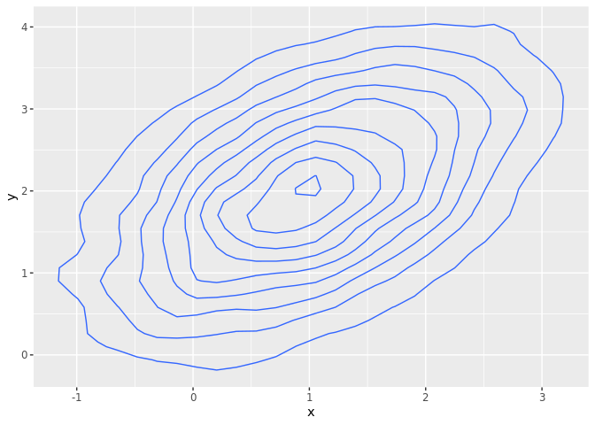

```r
p = ggplot(dplot,aes(x = x,y = y))
p + geom_contour(aes(z = value)) # 等高线图
```

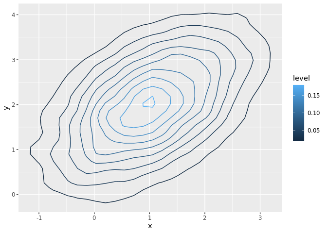

```r
p + geom_contour(aes(z = value,color = ..level..)) # 使用值的大小为等高线赋颜色
```

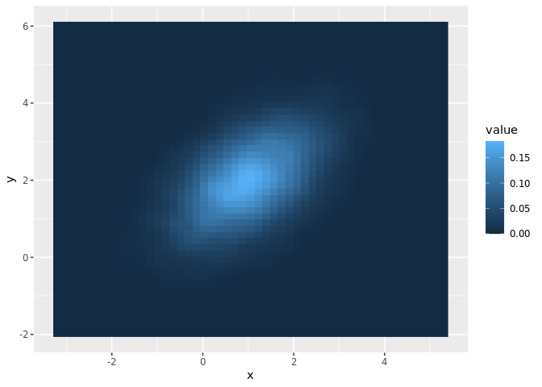

```r
p + geom_raster(mapping = aes(fill = value)) # 热力值图
```

## 1.4 多元变量的可视化

主要介绍使用 `ggplot2` 来进行可视化。

### 1.4.1 散点图和散点特征映射

R软件自带的iris数据集中包含了三种鸢尾花的150个样品的测量数据， 每种各50个样品， 每个样品测量了花瓣、花萼的长、宽。绘制某一种花的花萼长宽的散点图：

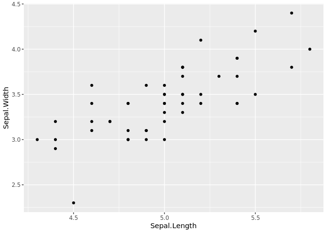

```r
library(ggplot2)
ggplot(iris[1:50,],aes(x = Sepal.Length,y = Sepal.Width)) +
  geom_point()
```

可以看到两个变量间存在一定的相关性。

进一步，绘制三种花花萼长宽之间的散点图，并使用颜色区分三种花：

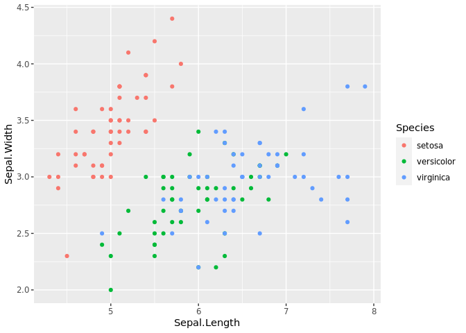

```r
ggplot(iris,aes(x = Sepal.Length,y = Sepal.Width,color = Species)) +
  geom_point()
```

可以看到三种花内部，花萼长宽均存在某种相关性，且三种花的花萼长宽分布存在差异。

进一步，将花瓣长度作为点的大小增加进入图像，绘制气泡图：

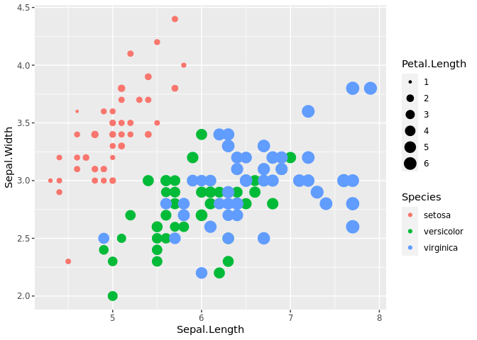

```r
ggplot(iris,aes(x = Sepal.Length,y = Sepal.Width,color = Species)) +
  geom_point(aes(size = Petal.Length))
```

### 1.4.2 散点图矩阵

`ggplot2` 包并没有提供专门的散点图矩阵绘制函数，但在 R 包 `GGally` 中有。继续以 `iris` 数据集为例，绘制花瓣、花萼的长、宽四个变量的散点图矩阵。操作如下：

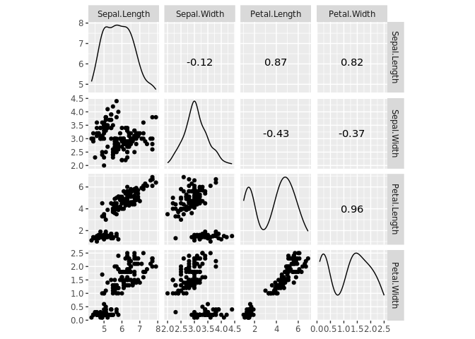

```r
# install.packages("GGally")
library(GGally)
ggscatmat(data = iris, columns = 1:4)
```

排列成矩阵的各个切片的下三角位置是两个变量的散点图， 对角线位置是单个变量的核密度估计， 上三角位置是两个变量的相关系数。

可以用 `color` 选项增加 `color` 映射， 可以用 `alpha` 指定透明度。如：

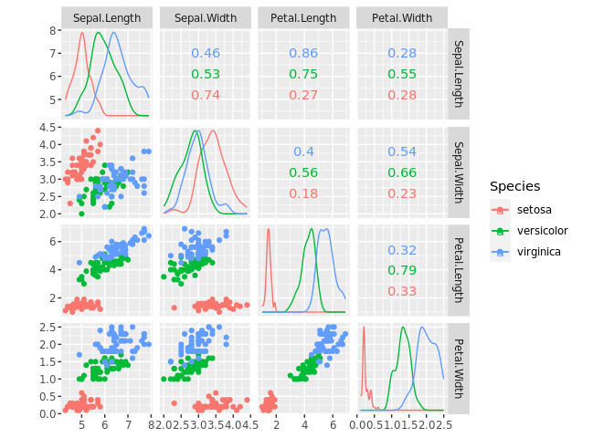

```r
ggscatmat(data = iris, columns = 1:4,
  color = "Species")
```

`GGally` 的 `ggpairs()` 函数提供了另一种矩阵图， 可以比较变量两两分布或者关系。 例如， 取 `iris` 数据集的花瓣长、花萼长与种类：

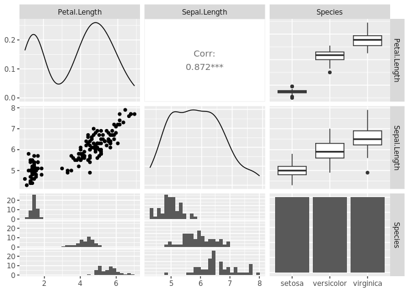

```r
ggpairs(
  data = iris,
  columns = c("Petal.Length", "Sepal.Length", "Species"))
```

### 1.4.3 相关系数矩阵图

多个变量之间的相关系数矩阵可以用色块图表示， ggcorrplot包提供了这样的功能：

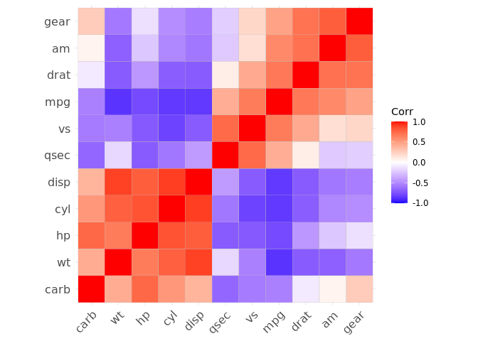

```r
# install.packages("ggcorrplot")
library(ggcorrplot)
data(mtcars)
ggcorrplot(cor(mtcars),
  hc.order=TRUE)
```

其中 `hc.order=TRUE` 对变量进行聚类， 使得正相关的变量排列在相邻位置。 可以用 `lab` 选项标出数值， 用 `cor_pmat()` 函数计算每个相关系数p值， 在 `ggcorrplot()` 中用选项 `p.mat` 输入p值矩阵后可以标出不显著的相关系数。